# test

Joseph Walker

3/26/2018

# Problem 1

**Use the dataset birth_data.csv to build a model that determines whether a baby is at risk, i.e., needs immediate emergency care or extra medical attention immediately upon birth.**

*Requirements*

- Use caret for your solution, see:https://topepo.github.io/caret/
- Use caret-based data preparation to prepare the data for your models.
- Use caret to fit (1) logistic regression and (2) GBM models.
- Use caret to tune your models appropriately.
- Use caret (and other methods, if desired) to evaluate and compare the performance of each type of model using appropriate methods (e.g., confusion matrix, ROC, AUC).

Let’s begin by loading the dataset.

```r
#load required packages
library(tidyverse)
library(caret)
library(ggplot2)

#read in dataset
birth_data <- read_csv(file = "birth_data.csv")

#examine the dataset
glimpse(birth_data)
```

```
## Observations: 26,313
## Variables: 15
## $ PWGT          <int> 155, 140, 151, 118, 134, 117, 160, 98, 132, 135,...
## $ UPREVIS       <int> 14, 13, 15, 4, 11, 18, 1, 8, 15, 7, 4, 10, 6, 14...
## $ CIG_REC       <lgl> FALSE, FALSE, FALSE, FALSE, FALSE, FALSE, TRUE, ...
## $ GESTREC3      <chr> ">= 37 weeks", ">= 37 weeks", ">= 37 weeks", ">=...
## $ DPLURAL       <chr> "single", "single", "single", "single", "single"...
## $ ULD_MECO      <lgl> TRUE, FALSE, FALSE, FALSE, FALSE, TRUE, FALSE, F...
## $ ULD_PRECIP    <lgl> FALSE, FALSE, FALSE, FALSE, FALSE, FALSE, FALSE,...
## $ ULD_BREECH    <lgl> FALSE, FALSE, FALSE, FALSE, FALSE, FALSE, FALSE,...
## $ URF_DIAB      <lgl> FALSE, FALSE, FALSE, FALSE, FALSE, FALSE, FALSE,...
## $ URF_CHYPER    <lgl> FALSE, FALSE, FALSE, FALSE, FALSE, FALSE, FALSE,...
## $ URF_PHYPER    <lgl> FALSE, FALSE, FALSE, FALSE, FALSE, FALSE, FALSE,...
## $ URF_ECLAM     <lgl> FALSE, FALSE, FALSE, FALSE, FALSE, FALSE, FALSE,...
## $ atRisk        <lgl> FALSE, FALSE, FALSE, FALSE, FALSE, FALSE, FALSE,...
## $ DBWT          <int> 3714, 3715, 3447, 3175, 4038, 3410, 2981, 3065, ...
## $ ORIGRANDGROUP <int> 2, 4, 2, 6, 10, 7, 2, 7, 9, 6, 2, 0, 9, 1, 6, 3,...
```

There are two variables with a character data type. Let’s take a look at these variables more closely to see.

```r
birth_data %>%
  select(GESTREC3, DPLURAL) %>%
  distinct()
```

```
## # A tibble: 6 x 2
##   GESTREC3    DPLURAL
##   <chr>       <chr>
## 1 >= 37 weeks single
## 2 < 37 weeks  single
## 3 < 37 weeks  twin
## 4 >= 37 weeks twin
## 5 < 37 weeks  triplet or higher
## 6 >= 37 weeks triplet or higher
```

Because there are only two and three categories for each variable, respectively, it would better suit us to convert these variables to factors.

```r
birth_data <- within(birth_data, {
  GESTREC3 <- factor(GESTREC3)
  DPLURAL <- factor(DPLURAL)
})

#convert var names to lower case
names(birth_data) <- tolower(names(birth_data))
```

And one more thing we can do to make the dependent variable clearer for modeling purposes is to change the FALSE/TRUE to No/Yes. This will help down the road when we want to convert our classes into class probabilities for comparing models using performance metrics such AUC.

```r
#convert T/F to Yes/No
birth_data$atrisk <- ifelse(birth_data$atrisk == TRUE, "Yes", "No")

#convert atrisk to factor
birth_data$atrisk <- factor(birth_data$atrisk)
```

Now that we’ve cleaned up the variables, let’s examine the dataset at a high level.

```r
summary(birth_data)
```

```
##       pwgt          uprevis       cig_rec               gestrec3
##  Min.   : 74.0   Min.   : 0.00   Mode :logical   < 37 weeks : 3005
##  1st Qu.:126.0   1st Qu.: 9.00   FALSE:23928     >= 37 weeks:23308
##  Median :145.0   Median :11.00   TRUE :2385
##  Mean   :153.7   Mean   :11.17   NA's :0
##  3rd Qu.:172.0   3rd Qu.:13.00
##  Max.   :375.0   Max.   :49.00
##               dplural       uld_meco       uld_precip      uld_breech
##  single           :25440   Mode :logical   Mode :logical   Mode :logical
##  triplet or higher:   44   FALSE:25084     FALSE:25642     FALSE:24662
##  twin             :  829   TRUE :1229      TRUE :671       TRUE :1651
##                            NA's :0         NA's :0         NA's :0
##
##
##   urf_diab       urf_chyper      urf_phyper      urf_eclam
##  Mode :logical   Mode :logical   Mode :logical   Mode :logical
##  FALSE:24900     FALSE:25991     FALSE:25171     FALSE:26256
##  TRUE :1413      TRUE :322       TRUE :1142      TRUE :57
##  NA's :0         NA's :0         NA's :0         NA's :0
##
##
##  atrisk           dbwt      origrandgroup
##  No :25831   Min.   : 227   Min.   : 0.000
##  Yes:  482   1st Qu.:2977   1st Qu.: 2.000
##              Median :3316   Median : 5.000
##              Mean   :3273   Mean   : 5.059
##              3rd Qu.:3629   3rd Qu.: 8.000
##              Max.   :6165   Max.   :10.000
```

It looks like we’re working with a clean data set; no missing values (NA’s) or obvious discrepancies.

As is good modeling practice, first we begin by splitting our data set into a training and test set.

```r
#set seed for reproducibility
set.seed(1849)

#create training index vector
train_index <- createDataPartition(y = birth_data$atrisk, p = .8, list = F)

#create training set
birth_train <- birth_data[train_index, ]

#create test set
birth_test <- birth_data[-train_index, ]
```

## Logistic Regression

We’ll start by building a logistic regression model.

```r
#create train control object
glm_control <- trainControl(method = "cv", number = 10)

#build the model
glm_model <- train(atrisk ~ ., method = "glm", data = birth_train, family= "binomial", trControl = glm_control, trace = F)

#examine the model
glm_model
```

```
## Generalized Linear Model
##
## 21051 samples
##    14 predictor
##     2 classes: 'No', 'Yes'
##
## No pre-processing
## Resampling: Cross-Validated (10 fold)
## Summary of sample sizes: 18947, 18945, 18945, 18947, 18947, 18946, ...
## Resampling results:
##
##   Accuracy   Kappa
##   0.9818536  0.03388761
```

Using 10 fold cross-validation, we were able to build a model with an accuracy of 98.19 %

Now let’s apply the model performs on the test set.

```r
#make predictions on test set using glm model
glm_predictions <- predict(glm_model, newdata = birth_test)

#create Confusion Matrix
caret::confusionMatrix(glm_predictions, reference = birth_test$atrisk, positive = "Yes")
```

```
## Confusion Matrix and Statistics
##
##           Reference
## Prediction   No  Yes
##        No  5165   95
##        Yes    1    1
##
##                Accuracy : 0.9818
##                  95% CI : (0.9778, 0.9852)
##     No Information Rate : 0.9818
##     P-Value [Acc > NIR] : 0.5271
##
##                   Kappa : 0.0197
##  Mcnemar's Test P-Value : <2e-16
##
##             Sensitivity : 0.0104167
##             Specificity : 0.9998064
##          Pos Pred Value : 0.5000000
##          Neg Pred Value : 0.9819392
##              Prevalence : 0.0182440
##          Detection Rate : 0.0001900
##    Detection Prevalence : 0.0003801
##       Balanced Accuracy : 0.5051115
##
##        'Positive' Class : Yes
##
```

Again, the model results in a high accuracy of ~98% on the test set. Looking at the confusion matrix, one can gather that the model has a high specificity meaning that it does an excellent job at predicting cases where babies are not at risk at birth (True Negatives). On the other hand, the model has a very low sensitivity and predicts only 1 of the 96 total cases of babies being at risk correctly. This is obviously not a good thing as this could have life and death consequences for the cases of babies who truly are at risk but were not classified as such by the model.

## Gradient Boosting Machines

Let’s move on to some different models to see how they stack up against the GLM. In this section, we’ll continue using the `caret` package to make 2 **Gradient Boosting Machine** models.

First we’ll start with a basic **Generalized Boosted Regression - GBM** model. To start, we’ll make a train control object to specify that we want a 10-fold cross-validation repeated 10 times.

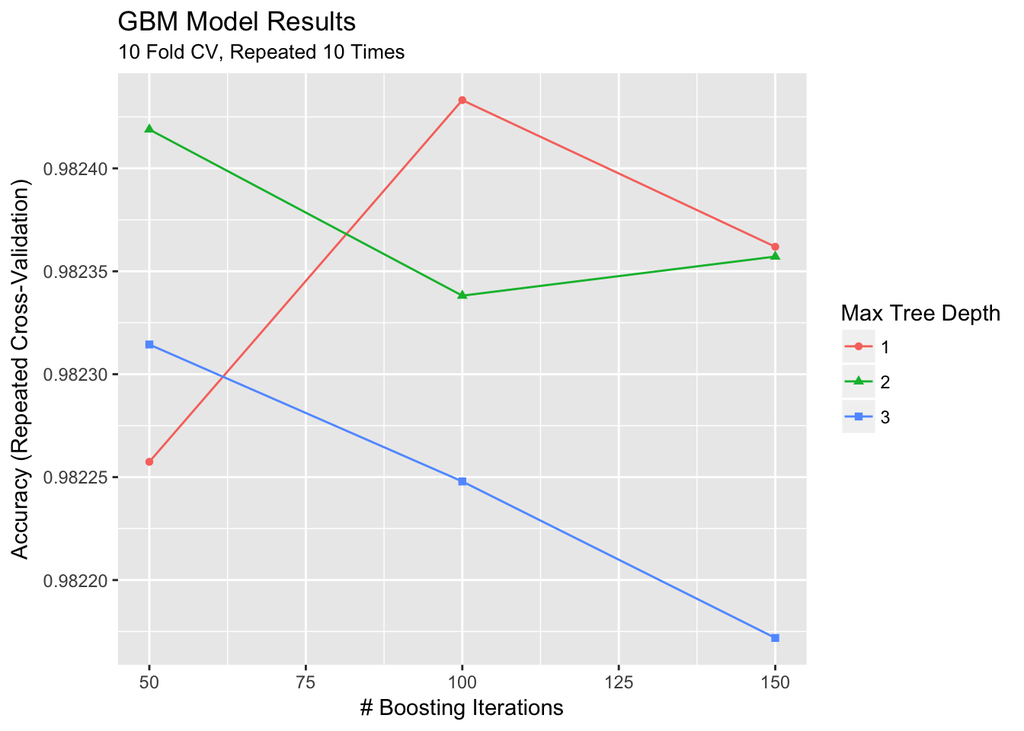

```r
#set seed for reproducibility
set.seed(5964)

#create train control for gbm
gbm_control <- trainControl(method = "repeatedcv", number = 10, repeats = 10)

#build gbm model
gbm_model <- train(atrisk ~ ., data = birth_train, method = "gbm", trControl = gbm_control, verbose = F)


#visualize the model
ggplot(gbm_model) +
  labs(title = "GBM Model Results", subtitle = "10 Fold CV, Repeated 10 Times")
```

```r
#examine the best tuning parameters
gbm_model$bestTune
```

```
##   n.trees interaction.depth shrinkage n.minobsinnode
## 2     100                 1       0.1             10
```